# lab_1

2. Find a data set to store in your project

```r
#install.packages("kernlab")
library(kernlab)
data(spam)
```

3. Create a new R Markdown document with html output
- Intermediate: have the document create both html and MS-Word output.
- Intermediate: would it work to also have the document create a presentation (e.g. beamer) from your Rmd file? Why or why not?

# Intro

1. Spam is a data set collected at Hewlett-Packard Labs, that classifies 4601 e-mails as spam or non-spam. In addition to this class label there are 57 variables indicating the frequency of certain words and characters in the e-mail.Questions about the data:
- Are there certain words that spam emails are more likely to contain?
- What’s the best way to block spam emails without filtering out non-spams?
2. Data spam is loaded.
3. Make a table of the first few rows of the data set.

```r
head(spam)
```

```
##   make address  all num3d  our over remove internet order mail receive
## 1 0.00    0.64 0.64     0 0.32 0.00   0.00     0.00  0.00 0.00    0.00
## 2 0.21    0.28 0.50     0 0.14 0.28   0.21     0.07  0.00 0.94    0.21
## 3 0.06    0.00 0.71     0 1.23 0.19   0.19     0.12  0.64 0.25    0.38
## 4 0.00    0.00 0.00     0 0.63 0.00   0.31     0.63  0.31 0.63    0.31
## 5 0.00    0.00 0.00     0 0.63 0.00   0.31     0.63  0.31 0.63    0.31
## 6 0.00    0.00 0.00     0 1.85 0.00   0.00     1.85  0.00 0.00    0.00
##   will people report addresses free business email  you credit your font
## 1 0.64   0.00   0.00      0.00 0.32     0.00  1.29 1.93   0.00 0.96    0
## 2 0.79   0.65   0.21      0.14 0.14     0.07  0.28 3.47   0.00 1.59    0
## 3 0.45   0.12   0.00      1.75 0.06     0.06  1.03 1.36   0.32 0.51    0
## 4 0.31   0.31   0.00      0.00 0.31     0.00  0.00 3.18   0.00 0.31    0
## 5 0.31   0.31   0.00      0.00 0.31     0.00  0.00 3.18   0.00 0.31    0
## 6 0.00   0.00   0.00      0.00 0.00     0.00  0.00 0.00   0.00 0.00    0
##   num000 money hp hpl george num650 lab labs telnet num857 data num415
```

[output cut: 34 more lines]

4. Include an image.

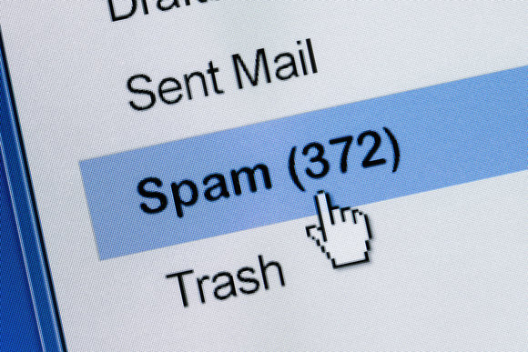

# Summary of Data

1. three variables: mail, you, will

```r
(mail_summary <- tapply(spam$mail, spam$type, summary))
```

```
## $nonspam
##    Min. 1st Qu.  Median    Mean 3rd Qu.    Max.
##  0.0000  0.0000  0.0000  0.1672  0.0000 18.1800
##
## $spam
##    Min. 1st Qu.  Median    Mean 3rd Qu.    Max.
##  0.0000  0.0000  0.0000  0.3505  0.5100  7.5500
```

```r
(you_summary <- tapply(spam$you, spam$type, summary))
```

```
## $nonspam
##    Min. 1st Qu.  Median    Mean 3rd Qu.    Max.
##   0.000   0.000   0.510   1.270   1.992  18.750
##
## $spam
##    Min. 1st Qu.  Median    Mean 3rd Qu.    Max.
##   0.000   1.200   2.180   2.265   3.250  12.500
```

```r
(will_summary <- tapply(spam$will, spam$type, summary))
```

```
## $nonspam
##    Min. 1st Qu.  Median    Mean 3rd Qu.    Max.
##  0.0000  0.0000  0.0000  0.5363  0.7525  9.6700
##
## $spam
##    Min. 1st Qu.  Median    Mean 3rd Qu.    Max.
##    0.00    0.00    0.43    0.55    0.84    6.25
```

2. The mean of mail is 0.16717 for nonspam and 0.3505074 for spam. The mean of you is 1.2703407 for nonspam and 2.2645394 for spam. The mean of will is 0.5363235 for nonspam and 0.5499724 for spam.
3. Explore your data with a minimum of 2 graphs.

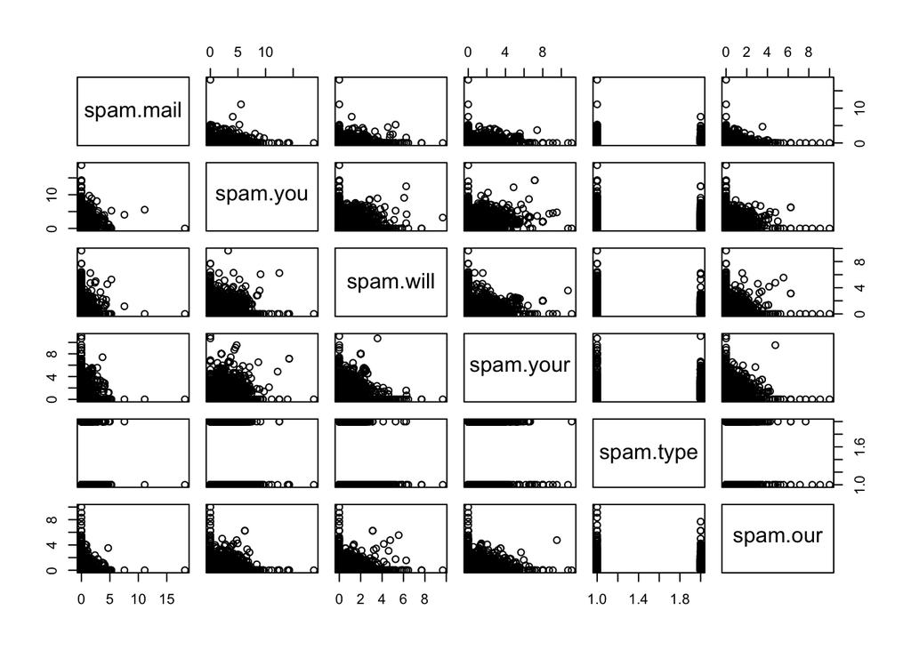

```r
spam2 <- data.frame(spam$mail, spam$you, spam$will, spam$your, spam$type, spam$our)
plot(spam2)
```

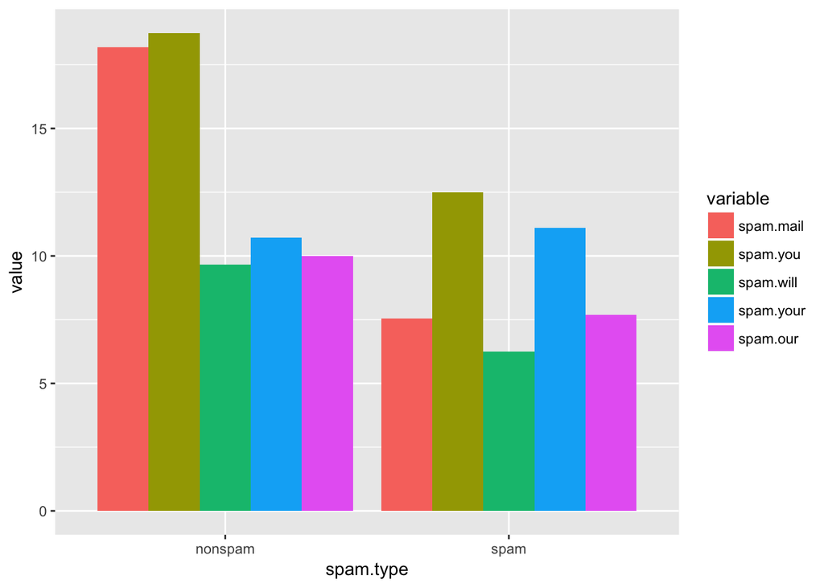

```r
spam3 <- melt(spam2, id.vars = "spam.type")
ggplot(data=spam3, aes(spam.type, value, fill=variable)) + geom_bar(stat = "identity", position = "dodge")
```

# Conclusion

9. | Name | Description |
   | --- | --- |
   | Comments | begin with the number sign (#) |
   | End a document within a stream | Three periods (…) |